# Genomics New Clothes

#### Nikolay Oskolkov, SciLifeLab, NBIS Long Term Support, nikolay.oskolkov@scilifelab.se

### Abstract

In this notebook, we will discuss how The Curse of Dimensionality may severely bias conclusions drawn from high-dimensional Genomics data.

### Table of Contents:

- Genomics High-Dimensional Data
- Hole in the Middle of High-Dimensional Data
- Pairwise Distances for High-Dimensional Data
- Loss of Information When Reducing Dimensions
- Random Matrices and Distributions of Eigenvalues

### Genomics High-Dimensional Data

Genomics is traditionally considered to be a king in the biological triade Genomics - Transcriptomics - Proteomics.

[figure not shown]

```python
from IPython.display import Image
Image('/home/nikolay/Documents/Medium/GenomicsNewClothes/GenomicsNewClothes.png', width = 1000)
```

### Hole in the Middle of High-Dimensional Data

Here we will demonstrate that the data points in high-dimensional space become concentrated on the surface and leave tha center empty. For simulating high-dimensional data uniformly distributed on a p-dimensional ball we will use the following principle adopted from this https://blogs.sas.com/content/iml/2016/04/06/generate-points-uniformly-in-ball.html great blog post:

> If Y is drawn from the uncorrelated multivariate normal distribution, then S = Y / ||Y|| has the uniform distribution on the unit d-sphere. Multiplying S by U1/d, where U has the uniform distribution on the unit interval (0,1), creates the uniform distribution in the unit d-dimensional ball.

This procedure reminds a generalization of the famous **Box-Mueller transform** for the random number generator https://en.wikipedia.org/wiki/Box%E2%80%93Muller_transform. Here we will start with simulating Y, normalizing it and generating X = (Y / norm(Y)) * U ^ (1 / p), where U ~ U[0,1], please see below:

```python
import numpy as np
from numpy.linalg import norm
import matplotlib.pyplot as plt

n = 1000
p = 2

# Normally distributed n data points in p-dimensional space
Y = np.random.randn(n, p)
print(Y)

plt.figure(figsize = (20, 15))
plt.scatter(Y[:,0], Y[:,1])
plt.title('Normally distributed n data points in 2-dimensional space', fontsize = 22)
plt.xlabel('Dimension 1', fontsize = 22)
plt.ylabel('Dimension 2', fontsize = 22)
plt.show()
```

[output not shown]

```
[[ 0.59350288 -1.61118398]
 [-1.72522415  0.82291818]
 [ 0.40654338 -0.21782162]
 ...
 [-0.86848155 -0.61714124]
 [-0.25917821  2.79548854]
 [ 1.94473043  0.94952069]]
```

Now let us normalize coordinates of each data point (vector) by the distance of the point from the center (0, 0) of the coordinates system. Here is the definition of normalized vectors https://mathworld.wolfram.com/NormalizedVector.html. As a result we will get a unit vector of data points.

$$ Y = \begin{pmatrix} x_1 & y_1\\ x_2 & y_2 \\ \dotsm & \dotsm \\ x_n & y_n \end{pmatrix} \Rightarrow \begin{pmatrix} \frac{x_1}{\sqrt{(x_1-0)^2+(y_1-0)^2}} & \frac{y_1}{\sqrt{(x_1-0)^2+(y_1-0)^2}}\\ \frac{x_2}{\sqrt{(x_2-0)^2+(y_2-0)^2}} & \frac{y_2}{\sqrt{(x_2-0)^2+(y_2-0)^2}} \\ \dotsm & \dotsm \\ \frac{x_n}{\sqrt{(x_n-0)^2+(y_n-0)^2}} & \frac{y_n}{\sqrt{(x_n-0)^2+(y_n-0)^2}} \end{pmatrix} $$

```python
list_of_norms = [np.sqrt((Y[i][0] - 0)**2 + (Y[i][1] - 0)**2) for i in range(Y.shape[0])]
list_of_norms[0:10]
```

```
[1.7170205234502167,
 1.9114373444604387,
 0.46121987671522946,
 1.1439206342258252,
 2.084096707316041,
 1.7761124096050893,
 1.4558646476947872,
 0.32490605701913144,
 1.2821256005101238,
 1.4601751478118334]
```

```python
normalized_Y = np.array([Y[i] / list_of_norms[i] for i in range(Y.shape[0])])
normalized_Y
```

```
array([[ 0.34565858, -0.93836035],
       [-0.9025795 ,  0.43052323],
       [ 0.88145242, -0.47227283],
       ...,
       [-0.81515282, -0.57924595],
       [-0.09231711,  0.99572966],
       [ 0.89860967,  0.43874897]])
```

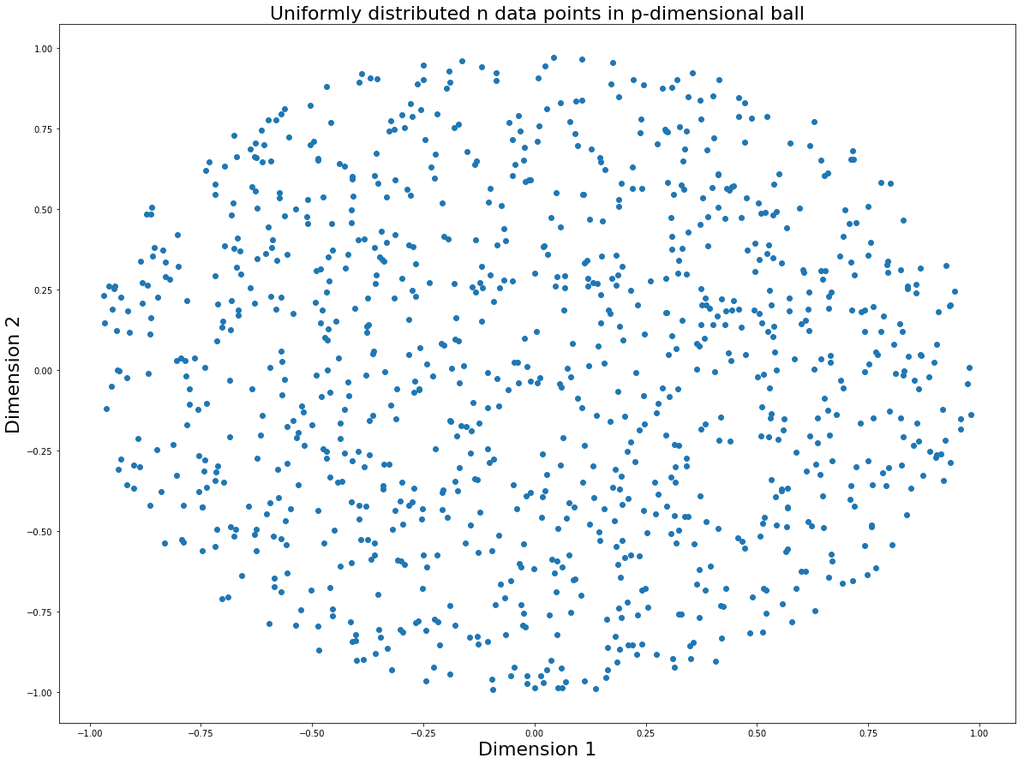

```python
u = np.random.rand(n, 1)
X = normalized_Y * u ** (1 / p)

plt.figure(figsize = (20, 15))
plt.scatter(X[:,0], X[:,1])
plt.title('Uniformly distributed n data points in p-dimensional ball', fontsize = 22)
plt.xlabel('Dimension 1', fontsize = 22)
plt.ylabel('Dimension 2', fontsize = 22)
plt.show()
```

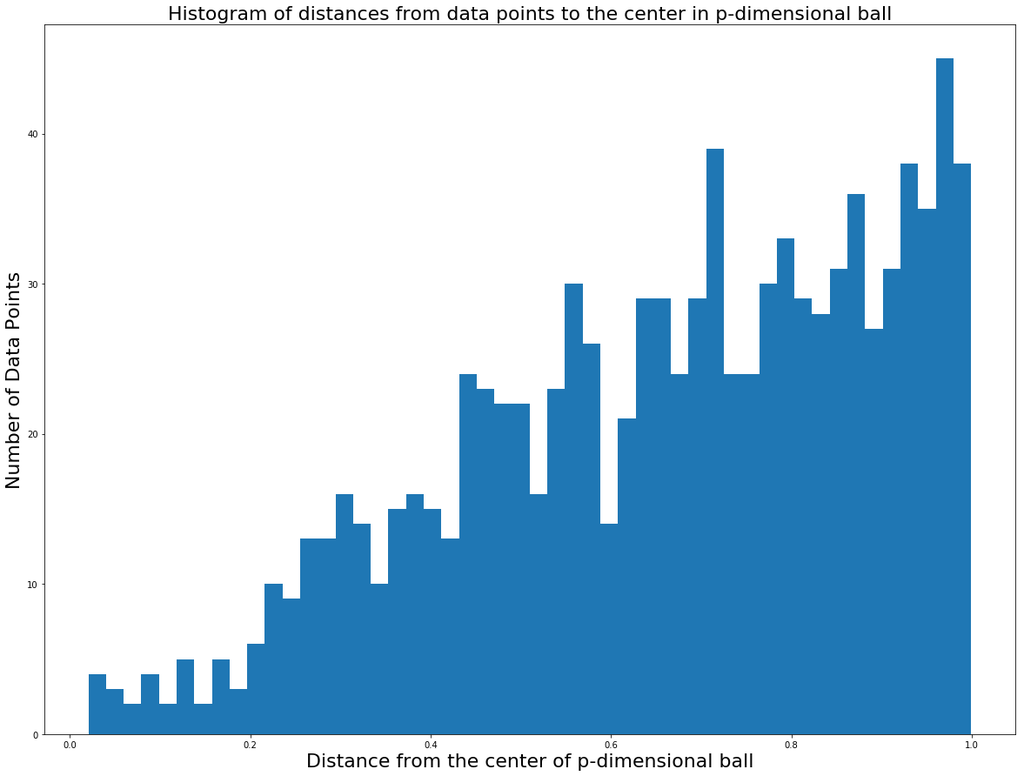

```python
plt.figure(figsize = (20, 15))
plt.hist([np.sqrt((X[i][0] - 0)**2 + (X[i][1] - 0)**2) for i in range(X.shape[0])], bins = 50)
plt.title('Histogram of distances from data points to the center in p-dimensional ball', fontsize = 22)
plt.xlabel('Distance from the center of p-dimensional ball', fontsize = 22)
plt.ylabel('Number of Data Points', fontsize = 22)
plt.show()
```

Now let us produce the histograms for a few spaces with different dimensions:

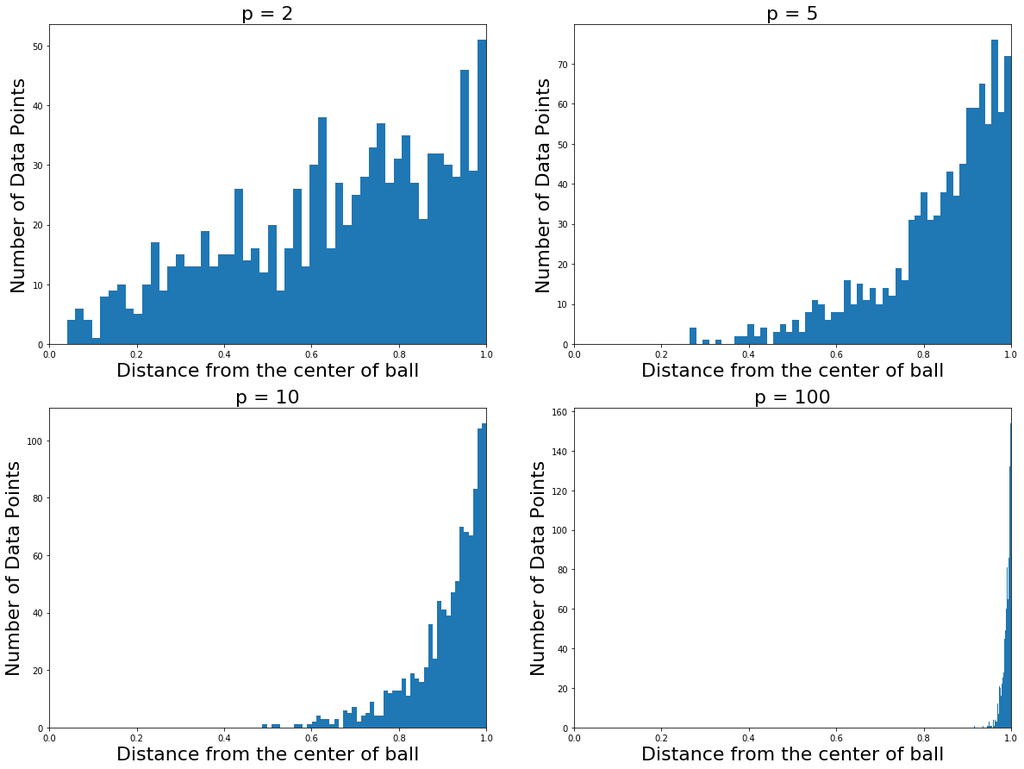

```python
import numpy as np
import matplotlib.pyplot as plt

n = 1000
plt.figure(figsize = (20, 15))

for index, p in enumerate([2, 5, 10, 100]):

    Y = np.random.randn(n, p)
    list_of_norms = [np.sqrt((Y[i][0] - 0)**2 + (Y[i][1] - 0)**2) for i in range(Y.shape[0])]
    normalized_Y = np.array([Y[i] / list_of_norms[i] for i in range(Y.shape[0])])
    u = np.random.rand(n, 1)
    X = normalized_Y * u ** (1 / p)

    plt.subplot(221 + index)
    plt.hist([np.sqrt((X[i][0] - 0)**2 + (X[i][1] - 0)**2) for i in range(X.shape[0])], bins = 50)
    plt.xlim([0, 1])
    #plt.scatter(X[:,0], X[:,1])
    plt.title('p = {}'.format(p), fontsize = 22)
    plt.xlabel('Distance from the center of ball', fontsize = 22)
    plt.ylabel('Number of Data Points', fontsize = 22)

plt.show()
```

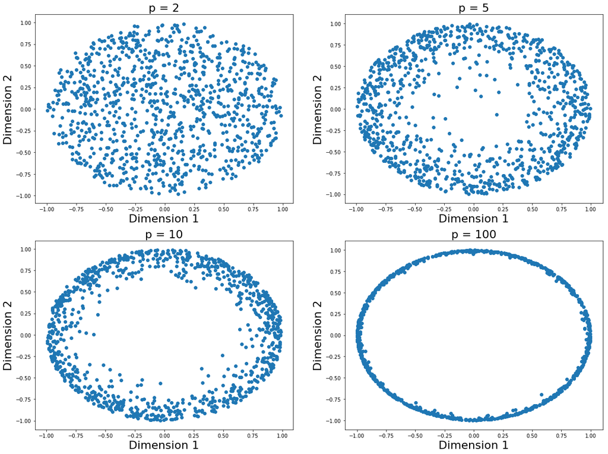

```python
import numpy as np
import matplotlib.pyplot as plt

n = 1000
plt.figure(figsize = (20, 15))

for index, p in enumerate([2, 5, 10, 100]):

    Y = np.random.randn(n, p)
    list_of_norms = [np.sqrt((Y[i][0] - 0)**2 + (Y[i][1] - 0)**2) for i in range(Y.shape[0])]
    normalized_Y = np.array([Y[i] / list_of_norms[i] for i in range(Y.shape[0])])
    u = np.random.rand(n, 1)
    X = normalized_Y * u ** (1 / p)

    plt.subplot(221 + index)
    #plt.hist([np.sqrt((X[i][0] - 0)**2 + (X[i][1] - 0)**2) for i in range(X.shape[0])], bins = 50)
    #plt.xlim([0, 1])
    plt.scatter(X[:,0], X[:,1])
    plt.title('p = {}'.format(p), fontsize = 22)
    plt.xlabel('Dimension 1', fontsize = 22)
    plt.ylabel('Dimension 2', fontsize = 22)

plt.show()
```

We can see that increasing the dimensionality of the data leads to shifting the data distribution from the center of the p-dimensional ball to the surface with the formation of a "hole" in the middle.

### Pairwise Distances for High-Dimensional Data

Here we will compute pairwise distances between data points for high-dimensional data and demonstrate that the distances increase as $\sqrt{p}$, where p is the number of dimensions.

```python
from sklearn.metrics.pairwise import euclidean_distances

n = 1000

mean_dist = []
std_dist = []
for p in range(2, 500, 1):

    Y = np.random.randn(n, p)
    dist = euclidean_distances(Y, Y)

    mean_dist.append(np.mean(dist))
    std_dist.append(np.std(dist))
```

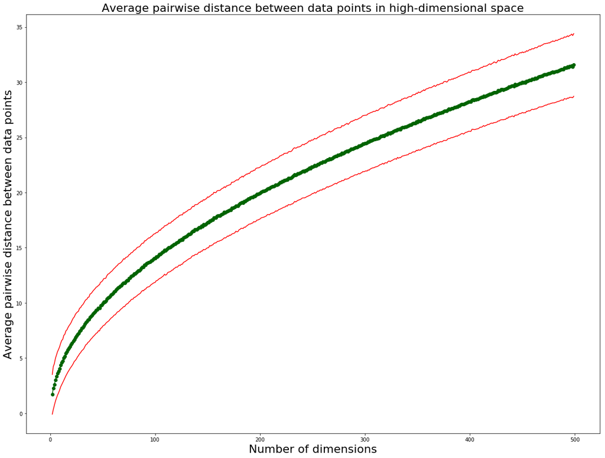

```python
plt.figure(figsize = (20, 15))
plt.plot(range(2, 500, 1), mean_dist, '-o', color = 'darkgreen')
plt.plot(range(2, 500, 1), [mean_dist[i] + 2*std_dist[i] for i in range(len(mean_dist))], color = 'r')
plt.plot(range(2, 500, 1), [mean_dist[i] - 2*std_dist[i] for i in range(len(mean_dist))], color = 'r')
plt.title('Average pairwise distance between data points in high-dimensional space', fontsize = 22)
plt.xlabel('Number of dimensions', fontsize = 22)
plt.ylabel('Average pairwise distance between data points', fontsize = 22)
plt.show()
```

```python
import statsmodels.api as sm
mod = sm.OLS(np.log(mean_dist), np.log(range(2, 500, 1)))
res = mod.fit()
res.summary()
```

OLS Regression Results

| Dep. Variable: | y | R-squared (uncentered): | 1.000 |
| --- | --- | --- | --- |
| Model: | OLS | Adj. R-squared (uncentered): | 1.000 |
| Method: | Least Squares | F-statistic: | 1.454e+06 |
| Date: | Mon, 01 Feb 2021 | Prob (F-statistic): | 0.00 |
| Time: | 17:48:02 | Log-Likelihood: | 734.17 |
| No. Observations: | 498 | AIC: | -1466. |
| Df Residuals: | 497 | BIC: | -1462. |
| Df Model: | 1 |  |  |
| Covariance Type: | nonrobust |  |  |

|  | coef | std err | t | P>\|t\| | [0.025 | 0.975] |
| --- | --- | --- | --- | --- | --- | --- |
| x1 | 0.5636 | 0.000 | 1205.756 | 0.000 | 0.563 | 0.565 |

| Omnibus: | 100.625 | Durbin-Watson: | 0.007 |
| --- | --- | --- | --- |
| Prob(Omnibus): | 0.000 | Jarque-Bera (JB): | 161.978 |
| Skew: | 1.274 | Prob(JB): | 6.71e-36 |
| Kurtosis: | 4.145 | Cond. No. | 1.00 |

Warnings:  
[1] Standard Errors assume that the covariance matrix of the errors is correctly specified.

We can see that the coefficeint is close to 0.5, i.e. log(dist) ~ 0.5 * log(p), therefore the average pairwise distance between two points increases as $\sqrt{p}$.

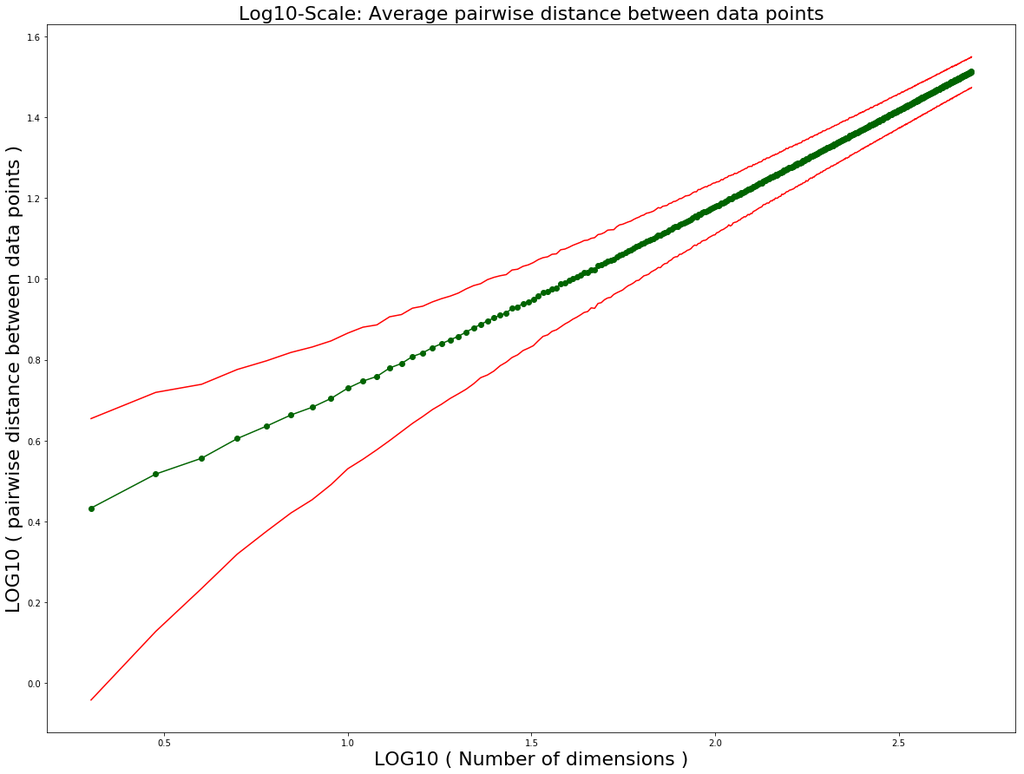

```python
plt.figure(figsize = (20, 15))
plt.plot(np.log10(range(2, 500, 1)), [np.log10(mean_dist[i] + 1) for i in range(len(mean_dist))],
         '-o', color = 'darkgreen')
plt.plot(np.log10(np.array(range(2, 500, 1))),
         [np.log10(mean_dist[i] + 2*std_dist[i] + 1) for i in range(len(mean_dist))], color = 'r')
plt.plot(np.log10(np.array(range(2, 500, 1))),
         [np.log10(mean_dist[i] - 2*std_dist[i] + 1) for i in range(len(mean_dist))], color = 'r')
plt.title('Log10-Scale: Average pairwise distance between data points', fontsize = 22)
plt.xlabel('LOG10 ( Number of dimensions )', fontsize = 22)
plt.ylabel('LOG10 ( pairwise distance between data points )', fontsize = 22)
plt.show()
```

Now let us plot density plots for pairwise distances in high-dimensional spaces:

```python
import numpy as np
import pandas as pd
from sklearn.metrics.pairwise import euclidean_distances

n = 1000

my_dist = []
my_dims = []
for p in [2, 32, 512]:

    Y = np.random.randn(n, p)

    my_dist.append(list((euclidean_distances(Y, Y) / np.max(euclidean_distances(Y, Y))).flatten()))
    my_dims.append([str(p)]*(n*n))

dist_df = pd.DataFrame({'DIST': [item for sublist in my_dist for item in sublist],
                        'DIMS': [item for sublist in my_dims for item in sublist]})
dist_df
```

|  | DIST | DIMS |
| --- | --- | --- |
| 0 | 0.000000 | 2 |
| 1 | 0.195701 | 2 |
| 2 | 0.248760 | 2 |
| 3 | 0.349663 | 2 |
| 4 | 0.268102 | 2 |
| ... | ... | ... |
| 2999995 | 0.879118 | 512 |
| 2999996 | 0.835057 | 512 |
| 2999997 | 0.921941 | 512 |
| 2999998 | 0.844034 | 512 |
| 2999999 | 0.000000 | 512 |

3000000 rows × 2 columns

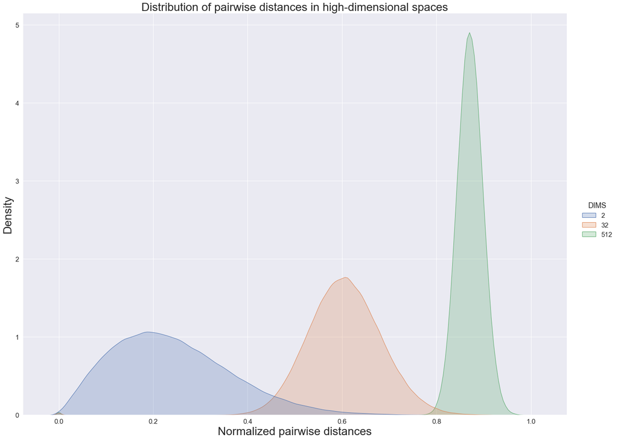

```python
import seaborn as sns
import matplotlib.pyplot as plt

sns.set(rc={'figure.figsize':(20, 15), "font.size": 25, "axes.titlesize": 25,
            "axes.labelsize": 25, "legend.fontsize": 25})
sns.set(font_scale = 1.5)


sns.displot(dist_df, x = "DIST", hue = "DIMS", kind = "kde", fill = True, height = 15, aspect = 20 / 15)

plt.title('Distribution of pairwise distances in high-dimensional spaces', fontsize = 28)
plt.xlabel('Normalized pairwise distances', fontsize = 28)
plt.ylabel('Density', fontsize = 28)

plt.show()
```

Now we will check how the distance between each data point and its nearest / middle / farthest neighbor changes with dimensionality of the data.

```python
from sklearn.metrics.pairwise import euclidean_distances

n = 1000
p_min = 2
p_max = 1000

mean_nearest_n_dist = []
mean_middle_n_dist = []
mean_farthest_n_dist = []
for p in range(p_min, p_max, 1):

    Y = np.random.randn(n, p)
    dist = euclidean_distances(Y, Y)

    nearest_n_dist = []
    middle_n_dist = []
    farthest_n_dist = []
    for j in range(dist.shape[0]):

        sorted_dist = np.sort(dist[j,:])

        nearest_n_dist.append(sorted_dist[1])
        middle_n_dist.append(np.median(sorted_dist))
        farthest_n_dist.append(sorted_dist[-1])

    mean_nearest_n_dist.append(np.mean(nearest_n_dist))
    mean_middle_n_dist.append(np.mean(middle_n_dist))
    mean_farthest_n_dist.append(np.mean(farthest_n_dist))
```

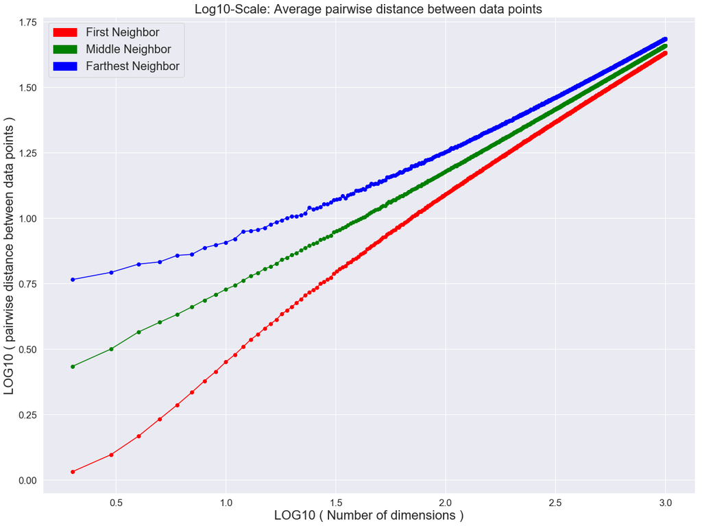

```python
import matplotlib.patches as mpatches

plt.figure(figsize = (20, 15))
plt.plot(np.log10(range(p_min, p_max, 1)),
         [np.log10(mean_nearest_n_dist[i] + 1) for i in range(len(mean_nearest_n_dist))],
         '-o', color = 'red')
plt.plot(np.log10(range(p_min, p_max, 1)),
         [np.log10(mean_middle_n_dist[i] + 1) for i in range(len(mean_middle_n_dist))],
         '-o', color = 'green')
plt.plot(np.log10(range(p_min, p_max, 1)),
         [np.log10(mean_farthest_n_dist[i] + 1) for i in range(len(mean_farthest_n_dist))],
         '-o', color = 'blue')
plt.title('Log10-Scale: Average pairwise distance between data points', fontsize = 22)
plt.xlabel('LOG10 ( Number of dimensions )', fontsize = 22)
plt.ylabel('LOG10 ( pairwise distance between data points )', fontsize = 22)

my_legends = [mpatches.Patch(color = 'red', label = 'First Neighbor'),
              mpatches.Patch(color = 'green', label = 'Middle Neighbor'),
              mpatches.Patch(color = 'blue', label = 'Farthest Neighbor')]
plt.legend(handles = my_legends, fontsize = 20)

plt.show()
```

Let us now check how Pearson correlations between data points (samples) changes with increasing dimensionality of the data.

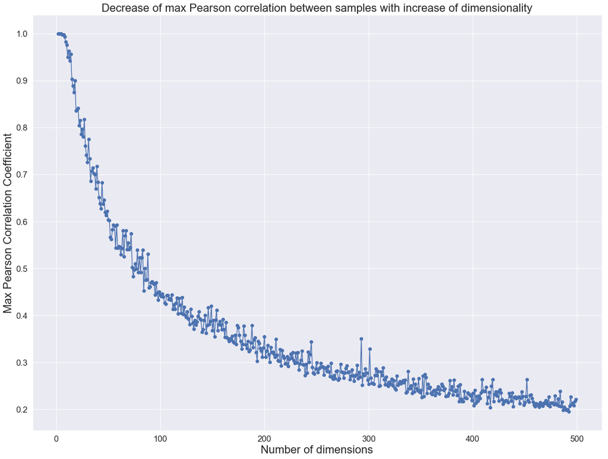

```python
n = 1000
p_min = 2
p_max = 500

max_corr = []
for p in range(p_min, p_max, 1):

    Y = np.random.randn(n, p)

    corr_matrix = np.corrcoef(Y)
    np.fill_diagonal(corr_matrix, 0)
    max_corr.append(np.max(corr_matrix))

plt.figure(figsize = (20, 15))
plt.plot(range(p_min, p_max, 1), max_corr, '-o')
plt.title('Decrease of max Pearson correlation between samples with increase of dimensionality', fontsize = 22)
plt.xlabel('Number of dimensions', fontsize = 22)
plt.ylabel('Max Pearson Correlation Coefficient', fontsize = 22)
plt.show()
```

We can see that samples become less ans less correlated with increasing the dimensionality of the data. For example, at dimensionality p > 100, we do not see any pair of samples correlated stronger than Pearson rho = 0.5, this is a very weak correlation. this means that in high dimensions, samples stop grouping with each other and become more and more independent from each other.

### Loss of Information When Reducing Dimensions

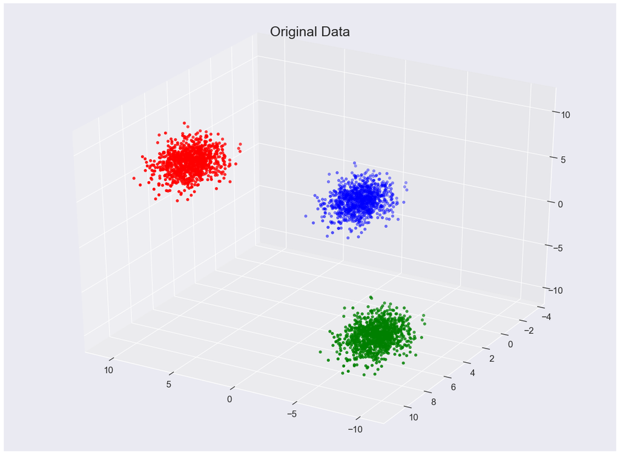

```python
from mpl_toolkits import mplot3d
plt.figure(figsize=(20,15))

n = 1000
p = 3

X1 = np.random.randn(n, p)
X2 = X1 + np.max(X1)*2
X3 = X1 - np.max(X1)*2
X3[:,1] = X3[:,1] + np.max(X1)*4
X = np.vstack([X1, X2, X3])
y = np.array([['blue']*n, ['red']*n, ['green']*n])
y = y.flatten()

ax = plt.axes(projection = '3d')
ax.scatter3D(X[:, 0], X[:, 1], X[:, 2], c = y)
ax.view_init(30, 120)
plt.title('Original Data', fontsize = 25)
plt.show()
```

For simplicity, here we will consider a 2D original data set and will try to see if it is possible to further reduce dimensions in this data set.

[output not shown]

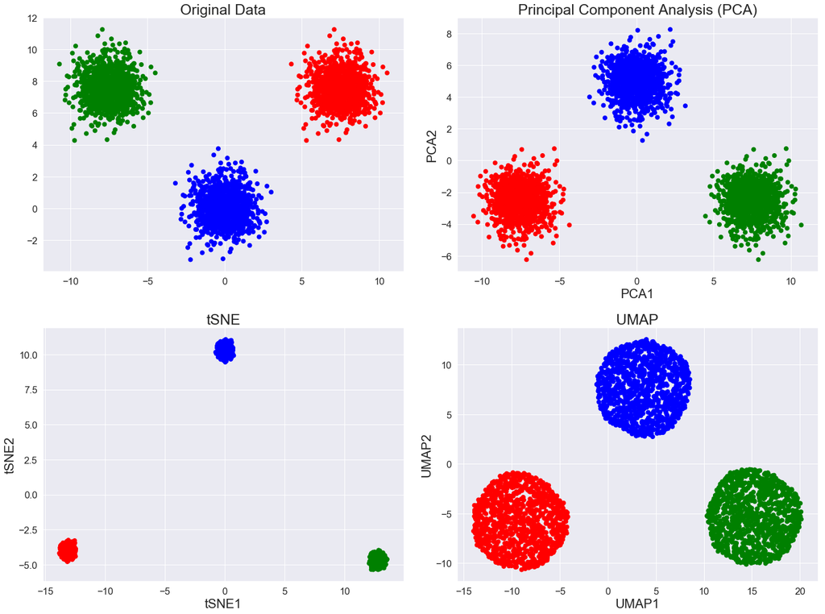

```python
import warnings
warnings.filterwarnings("ignore")

import matplotlib
import numpy as np
from umap.umap_ import UMAP
import matplotlib.pyplot as plt
from sklearn.manifold import TSNE
from sklearn.decomposition import PCA

n = 1000
p = 2

X1 = np.random.randn(n, p)
X2 = X1 + np.max(X1)*2
X3 = X1 - np.max(X1)*2
X3[:,1] = X3[:,1] + np.max(X1)*4
X = np.vstack([X1,X2,X3])
y = np.array([['blue']*n, ['red']*n, ['green']*n])
y = y.flatten()

figure = plt.figure(figsize = (20, 15))
matplotlib.rcParams.update({'font.size': 22})

#ORIGINAL DATA
plt.subplot(221)
plt.scatter(X[:, 0], X[:, 1], c = y, s = 50)
#ax = plt.axes(projection = '3d')
#ax.scatter3D(X[:, 0], X[:, 1], X[:, 2], c = y, s = 50)
#ax.view_init(30, 120)
plt.title('Original Data', fontsize = 25)
#plt.xlabel("Dimension 1", fontsize = 22)
#plt.ylabel("Dimension 2", fontsize = 22)

#PCA RECONSTRUCTION
plt.subplot(222)
X_reduced = PCA(n_components = 2).fit_transform(X)
plt.scatter(X_reduced[:, 0], X_reduced[:, 1], c = y, s = 50)
plt.title('Principal Component Analysis (PCA)', fontsize = 25)
plt.xlabel("PCA1", fontsize = 22); plt.ylabel("PCA2", fontsize = 22)

#TSNE RECONSTRUCTION
plt.subplot(223)
model = TSNE(learning_rate = 200, n_components = 2, random_state = 123, perplexity = 1000,
             init = X_reduced, n_iter = 1000, verbose = 2)
tsne = model.fit_transform(X)
plt.scatter(tsne[:, 0], tsne[:, 1], c = y, s = 50)
plt.title('tSNE', fontsize = 25); plt.xlabel("tSNE1", fontsize = 22); plt.ylabel("tSNE2", fontsize = 22)

#UMAP RECONSTRUCTION
plt.subplot(224)
model = UMAP(learning_rate = 1, n_components = 2, min_dist = 1, n_neighbors = 1000,
             init = X_reduced, n_epochs = 1000, verbose = 2)
umap = model.fit_transform(X)
plt.scatter(umap[:, 0], umap[:, 1], c = y, s = 50)
plt.title('UMAP', fontsize = 25); plt.xlabel("UMAP1", fontsize = 22); plt.ylabel("UMAP2", fontsize = 22)

figure.tight_layout()
plt.show()
```

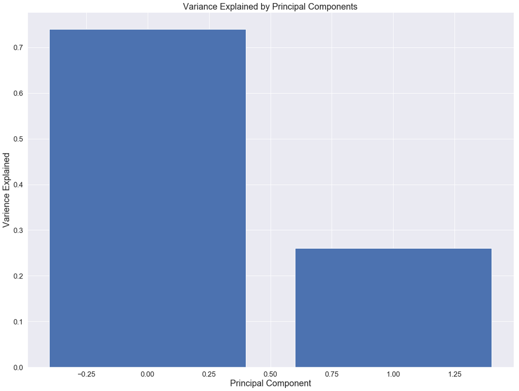

```python
pca = PCA(n_components = p).fit(X)

plt.figure(figsize = (20, 15))
index = np.arange(len(pca.explained_variance_ratio_))
plt.bar(index, pca.explained_variance_ratio_)
plt.title('Variance Explained by Principal Components', fontsize = 20)
plt.xlabel("Principal Component", fontsize = 20)
plt.ylabel("Varience Explained", fontsize = 20)
plt.show()
```

Here we can observe that if we consider only PC1, tSNE1 or UMAP1, the distances between the clusters will be violated compared to their original values, so we can not really reduce dimensions from the 2D down to 1D without loosing information about mutual positions of the clusters.

Let us now check the case of data with intrinsic one dimension. In this case we can very well reduce dimensions without loosing information. In other words, the dimensionality reduction techniques will preserve original distances between the 3 clusters.

[output not shown]

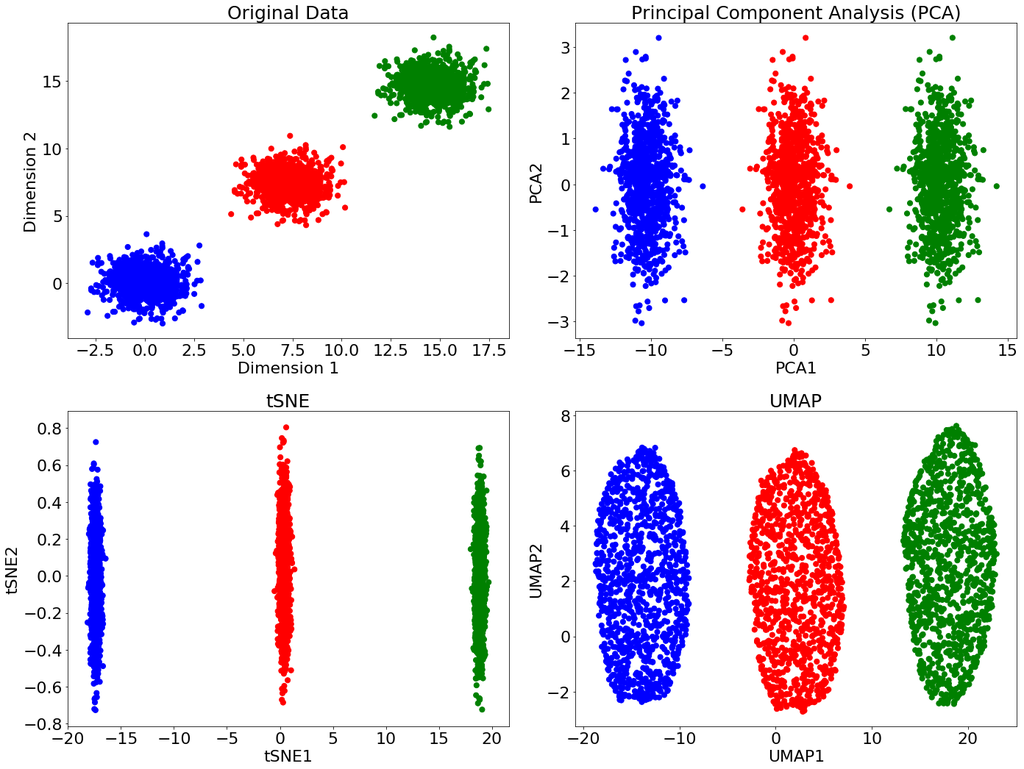

```python
import warnings
warnings.filterwarnings("ignore")

import matplotlib
import numpy as np
from umap.umap_ import UMAP
import matplotlib.pyplot as plt
from sklearn.manifold import TSNE
from sklearn.decomposition import PCA

n = 1000
p = 2

X1 = np.random.randn(n, p)
X2 = X1 + np.max(X1)*2
X3 = X1 + np.max(X1)*4
X = np.vstack([X1,X2,X3])
y = np.array([['blue']*n, ['red']*n, ['green']*n])
y = y.flatten()

figure = plt.figure(figsize = (20, 15))
matplotlib.rcParams.update({'font.size': 22})

#ORIGINAL DATA
plt.subplot(221)
plt.scatter(X[:, 0], X[:, 1], c = y, s = 50)
plt.title('Original Data', fontsize = 25)
plt.xlabel("Dimension 1", fontsize = 22); plt.ylabel("Dimension 2", fontsize = 22)

#PCA RECONSTRUCTION
plt.subplot(222)
X_reduced = PCA(n_components = 2).fit_transform(X)
plt.scatter(X_reduced[:, 0], X_reduced[:, 1], c = y, s = 50)
plt.title('Principal Component Analysis (PCA)', fontsize = 25)
plt.xlabel("PCA1", fontsize = 22); plt.ylabel("PCA2", fontsize = 22)

#TSNE RECONSTRUCTION
plt.subplot(223)
model = TSNE(learning_rate = 200, n_components = 2, random_state = 123, perplexity = 1000,
             init = X_reduced, n_iter = 1000, verbose = 2)
tsne = model.fit_transform(X)
plt.scatter(tsne[:, 0], tsne[:, 1], c = y, s = 50)
plt.title('tSNE', fontsize = 25); plt.xlabel("tSNE1", fontsize = 22); plt.ylabel("tSNE2", fontsize = 22)

#UMAP RECONSTRUCTION
plt.subplot(224)
model = UMAP(learning_rate = 1, n_components = 2, min_dist = 1, n_neighbors = 1000,
             init = X_reduced, n_epochs = 1000, verbose = 2)
umap = model.fit_transform(X)
plt.scatter(umap[:, 0], umap[:, 1], c = y, s = 50)
plt.title('UMAP', fontsize = 25); plt.xlabel("UMAP1", fontsize = 22); plt.ylabel("UMAP2", fontsize = 22)

figure.tight_layout()
plt.show()
```

In contrast to the previous example, considering just PC1, tSNE1 or UMAP1 will correctly preserve the inter-cluster distances. Therefore we can reduce dimensions from the original 2D down to 1D without loosing information about mutual positions of the clusters.

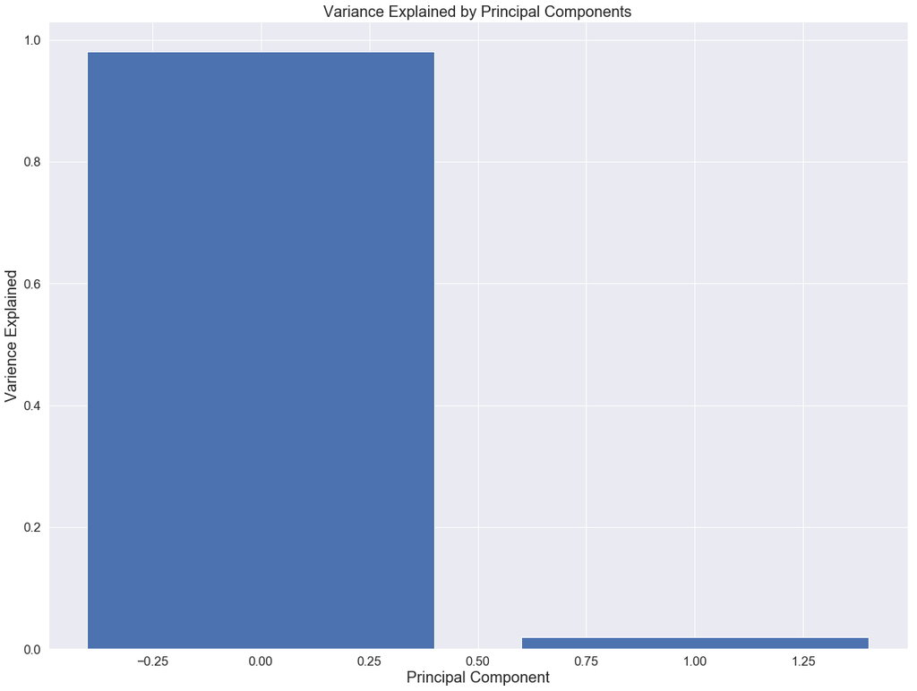

```python
pca = PCA(n_components = p).fit(X)

plt.figure(figsize = (20, 15))
index = np.arange(len(pca.explained_variance_ratio_))
plt.bar(index, pca.explained_variance_ratio_)
plt.title('Variance Explained by Principal Components', fontsize = 20)
plt.xlabel("Principal Component", fontsize = 20)
plt.ylabel("Varience Explained", fontsize = 20)
plt.show()
```

Now let us generate high-dimensional clusters for different types of symmetry and check variance explained by leading principal components.

```python
from sklearn.datasets import make_blobs

n = 1000
p = 4

centers = [(-5, -5, -5, -5), (0, 0, 0, 0), (5, 5, 5, 5), (10, 10, 10, 10)]
centers[0] = centers[0] + np.random.normal(0, 5, p)
centers[1] = centers[1] + np.random.normal(0, 5, p)
centers[2] = centers[2] + np.random.normal(0, 5, p)
centers[3] = centers[3] + np.random.normal(0, 5, p)

#centers = [[0]*p, (0, 0, 0, 0), (5, 5, 5, 5), (10, 10, 10, 10)]
#tuple([0 + 1]*p)

X, y = make_blobs(n_samples = n, n_features = p, centers = centers, shuffle = False, random_state=42)
```

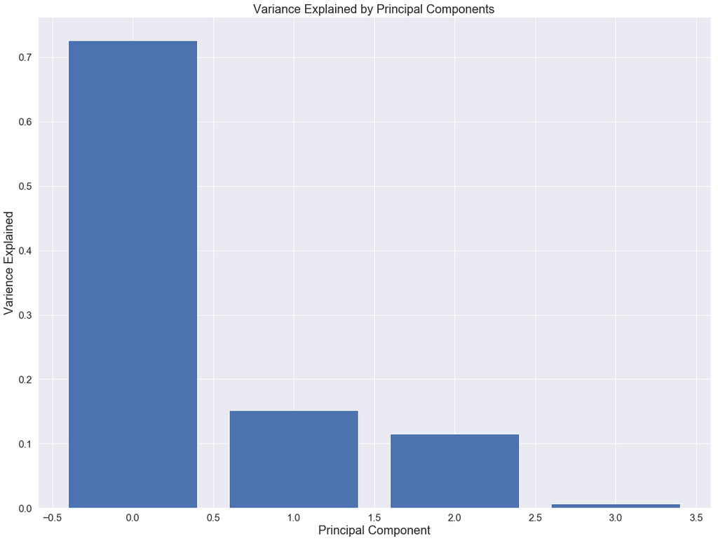

```python
pca = PCA(n_components = p).fit(X)

plt.figure(figsize = (20, 15))
index = np.arange(len(pca.explained_variance_ratio_))
plt.bar(index, pca.explained_variance_ratio_)
plt.title('Variance Explained by Principal Components', fontsize = 20)
plt.xlabel("Principal Component", fontsize = 20)
plt.ylabel("Varience Explained", fontsize = 20)
plt.show()
```

```python
from sklearn.datasets import make_blobs

n = 1000
p = 4

centers = [(5, 0, 0, 0), (0, 5, 0, 0), (0, 0, 5, 0), (0, 0, 0, 5)]
centers[0] = centers[0] + np.random.normal(0, 0.3, p)
centers[1] = centers[1] + np.random.normal(0, 0.3, p)
centers[2] = centers[2] + np.random.normal(0, 0.3, p)
centers[3] = centers[3] + np.random.normal(0, 0.3, p)

X, y = make_blobs(n_samples = n, n_features = p, centers = centers, shuffle = False, random_state=42)
```

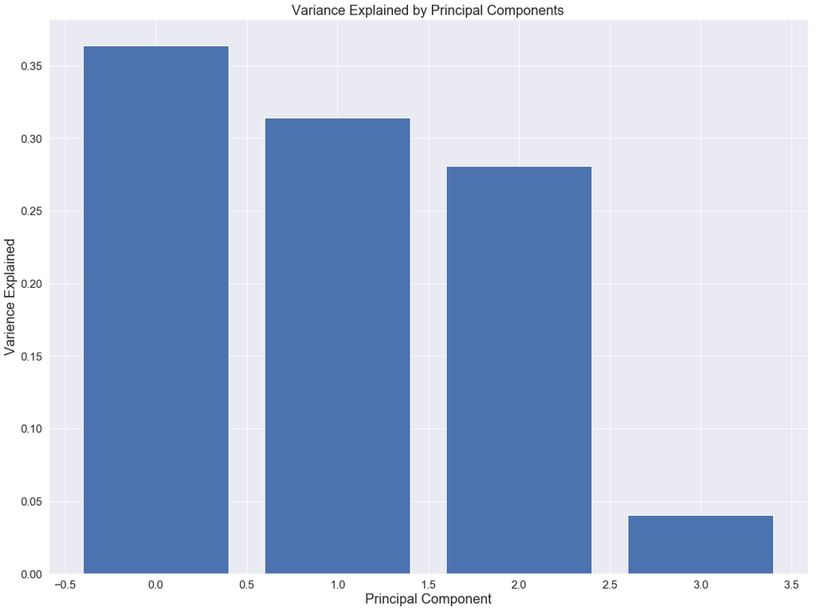

```python
pca = PCA(n_components = p).fit(X)

plt.figure(figsize = (20, 15))
index = np.arange(len(pca.explained_variance_ratio_))
plt.bar(index, pca.explained_variance_ratio_)
plt.title('Variance Explained by Principal Components', fontsize = 20)
plt.xlabel("Principal Component", fontsize = 20)
plt.ylabel("Varience Explained", fontsize = 20)
plt.show()
```

### Random Matrices and Distributions of Eigenvalues

Let us display distributions of eigen values for different ratios of n and p:

```python
import pandas as pd
from sklearn.decomposition import PCA

n = [10000, 1000, 1000]
p = [1000, 1000, 10000]

eigen = []
np_ratio = []
for i in range(len(n)):

    X = np.random.randn(n[i], p[i])
    pca = PCA().fit(X)

    eigen.append(list(pca.explained_variance_))
    np_ratio.append([str(n[i] / p[i])]*min(n[i], p[i]))

eigen_df = pd.DataFrame({'EIGEN': [item for sublist in eigen for item in sublist],
                        'NP_RATIO': [item for sublist in np_ratio for item in sublist]})

eigen_df['DIMENSION'] = np.where(eigen_df['NP_RATIO'] == '10.0','P << N',
                           np.where(eigen_df['NP_RATIO'] == '1.0', 'P ~ N', 'P >> N'))

#eigen_df['EIGEN'] = np.log10(eigen_df['EIGEN'] + 1)

eigen_df
```

|  | EIGEN | NP_RATIO | DIMENSION |
| --- | --- | --- | --- |
| 0 | 1.721440e+00 | 10.0 | P << N |
| 1 | 1.707467e+00 | 10.0 | P << N |
| 2 | 1.700421e+00 | 10.0 | P << N |
| 3 | 1.692512e+00 | 10.0 | P << N |
| 4 | 1.692204e+00 | 10.0 | P << N |
| ... | ... | ... | ... |
| 2995 | 4.785680e+00 | 0.1 | P >> N |
| 2996 | 4.774313e+00 | 0.1 | P >> N |
| 2997 | 4.755711e+00 | 0.1 | P >> N |
| 2998 | 4.701196e+00 | 0.1 | P >> N |
| 2999 | 1.402039e-29 | 0.1 | P >> N |

3000 rows × 3 columns

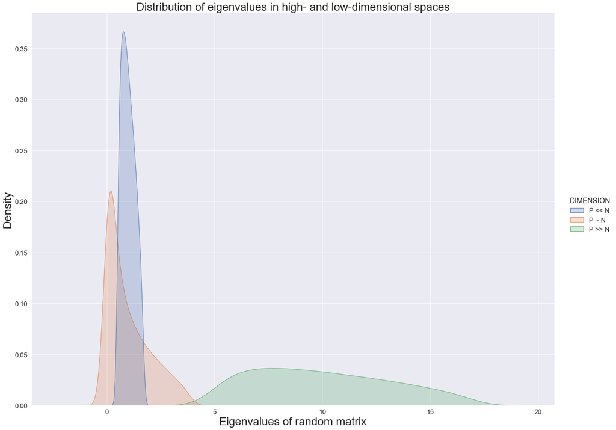

```python
import seaborn as sns
import matplotlib.pyplot as plt

sns.set(rc={'figure.figsize':(20, 15), "font.size": 25, "axes.titlesize": 25,
            "axes.labelsize": 25, "legend.fontsize": 25})
sns.set(font_scale = 1.5)


sns.displot(eigen_df, x = "EIGEN", hue = "DIMENSION", kind = "kde", fill = True, height = 15, aspect = 20 / 15)

plt.title('Distribution of eigenvalues in high- and low-dimensional spaces', fontsize = 28)
plt.xlabel('Eigenvalues of random matrix', fontsize = 28)
plt.ylabel('Density', fontsize = 28)

plt.show()
```

$$A = XX^T = \frac{1}{N}\sum_{ij}x_ix_j$$$$N = N_{pop1} + N_{pop2} + N_{pop3} + ... = \sum_k N_k$$$$A_{uneven}=\sum_{ijk}\frac{1}{N_k}x_{ik}x_{jk}$$

$$\rm{Polygenic\,Risk\,Score\,(PRS)}\,=\,\beta_1 SNP_1\,+\,\beta_2 SNP_2\,+\,\dots\,+\,\beta_m SNP_m\,\,\leftarrow\rm{training}$$$$\rm{Phen}\,\, \sim \,\,\rm{PRS}\,\,\leftarrow\rm{validation}$$

$$\rm{Pairwise\,Euclidean\,Distance \sim \sqrt{p}}$$